```python
# automatically show plots inside the notebook
%matplotlib inline

# reload all modules before executing code
%load_ext autoreload
%autoreload 2
```

```python
# you will use this notebook as a basis to walk us through what you did
```

```python
import pandas as pd
import numpy as np
import matplotlib.pylab as plt
import seaborn as sns

from sklearn.metrics import classification_report
from sklearn.linear_model import LogisticRegression
from sklearn.model_selection import cross_val_score, GridSearchCV, train_test_split
from sklearn.pipeline import make_pipeline
from sklearn.manifold import TSNE
from sklearn.preprocessing import StandardScaler, MinMaxScaler
from sklearn.decomposition import PCA
from sklearn.feature_selection import SelectKBest, f_classif, mutual_info_classif, SelectFromModel
from sklearn.svm import SVC
from sklearn.neighbors import KNeighborsClassifier
from sklearn.tree import DecisionTreeClassifier

from sklearn.ensemble import RandomForestClassifier, GradientBoostingClassifier, ExtraTreesClassifier

RANDOM_STATE = 42
```

# First look and visualization

```python
features = pd.read_csv('../data/features.csv')
labels = pd.read_csv('../data/labels.csv')
```

The data doesn't look big and the number of features is bigger than the number of data points, so we should be careful with overfitting. In this case it's better to use linear models, but we need to scale the features before that for better convergence.

```python
print("Shape of the data: ", features.shape)
features.head(10)
```

```
Shape of the data:  (288, 688)
```

|  | Patient ID | Feature0 | Feature1 | Feature2 | Feature3 | Feature4 | Feature5 | Feature6 | Feature7 | Feature8 | ... | Feature677 | Feature678 | Feature679 | Feature680 | Feature681 | Feature682 | Feature683 | Feature684 | Feature685 | Feature686 |
| --- | --- | --- | --- | --- | --- | --- | --- | --- | --- | --- | --- | --- | --- | --- | --- | --- | --- | --- | --- | --- | --- |
| 0 | 1 | 743 | 3594 | 81 | 23154 | 887 | 491 | 368 | 1322 | 14624 | ... | 0.051950 | 0.057096 | 4.309440 | 0.827737 | 0.813420 | 1.118799 | 0.635217 | 1.143215 | 1.450378 | 0.790279 |
| 1 | 2 | 249 | 1523 | 373 | 60306 | 1347 | 1016 | 201 | 1586 | 45525 | ... | 0.023671 | 0.026299 | 33.007541 | 1.157097 | 0.712491 | 1.149333 | 0.709755 | 1.126794 | 1.171539 | 0.960270 |
| 2 | 4 | 150 | 815 | 88 | 54361 | 1558 | 452 | 105 | 1758 | 47862 | ... | 0.030360 | 0.032339 | 55.780435 | 0.936845 | 0.621701 | 0.688862 | 0.635621 | 0.835548 | 0.894580 | 0.871643 |
| 3 | 5 | 376 | 2095 | 276 | 58681 | 1307 | 814 | 241 | 1527 | 45351 | ... | 0.024164 | 0.026028 | 23.155095 | 1.188455 | 0.575252 | 1.237643 | 0.533353 | 1.076273 | 1.224851 | 1.133792 |
| 4 | 7 | 78 | 1946 | 109 | 34454 | 1577 | 415 | 513 | 1785 | 26612 | ... | 0.050253 | 0.051808 | 12.761692 | 1.477104 | 0.714410 | 1.062945 | 0.616509 | 0.979109 | 1.204625 | 0.888280 |
| 5 | 8 | 524 | 5546 | 65 | 51901 | 951 | 112 | 929 | 1148 | 34015 | ... | 0.022111 | 0.022119 | 6.642471 | 1.116701 | 0.566961 | 1.497652 | 0.536558 | 1.247205 | 1.297367 | 1.066056 |
| 6 | 9 | 79 | 969 | 23 | 16704 | 137 | 50 | 108 | 189 | 13176 | ... | 0.009153 | 0.011315 | 13.897864 | 1.086585 | 0.572878 | 1.053818 | 0.694391 | 0.920398 | 1.105554 | 0.892064 |
| 7 | 10 | 65 | 5422 | 30 | 23810 | 285 | 99 | 506 | 395 | 15736 | ... | 0.016870 | 0.016590 | 2.849865 | 1.012097 | 0.496486 | 0.875893 | 0.752709 | 0.796909 | 1.074456 | 0.824525 |
| 8 | 11 | 431 | 2907 | 54 | 37464 | 674 | 113 | 472 | 970 | 26807 | ... | 0.020810 | 0.025892 | 9.585380 | 1.201459 | 0.719179 | 1.432636 | 0.812969 | 1.168345 | 1.316483 | 1.236029 |
| 9 | 12 | 26 | 3198 | 21 | 66143 | 854 | 78 | 468 | 970 | 59152 | ... | 0.013856 | 0.014665 | 16.811784 | 0.673950 | 1.093552 | 0.667620 | 0.614909 | 0.586856 | 0.917970 | 0.717492 |

10 rows × 688 columns

We use the Patient ID to merge the features and the labels, but then we should drop it as it's a potential leak

```python
merged_df = pd.merge(features, labels, on='Patient ID')

merged_df.drop("Patient ID", axis=1, inplace=True)
```

Seems that we have an imbalanced dataset

```python
print("Sick: ", merged_df[merged_df['Sickness'] == 1].shape[0],
      "Healthy: ", merged_df[merged_df['Sickness'] == 0].shape[0])
```

```
Sick:  69 Healthy:  219
```

We don't have any null entries, that's cool. And all of the columns are numeric.

```python
for col in merged_df.columns:
    if merged_df[col].isnull().any():
        print('{0} , null_count : {1}'.format(col, merged_df[col].isnull().sum()))
```

```python
merged_df.dtypes.value_counts()
```

```
float64    676
int64       12
dtype: int64
```

Also we definitely have some categories (or ordinal) features with small of possible values. We can encode them differently or at least study more.

```python
for col in merged_df.columns:
    if  (merged_df[col].value_counts().shape[0] < 10):
        print(col)
```

```
Feature254
Feature255
Feature256
Feature257
Feature258
Feature259
Feature260
Feature261
Sickness
```

Let's visualize some of the features. We don't know the names of the features, so it's just for fun, but maybe we can see some correlations.

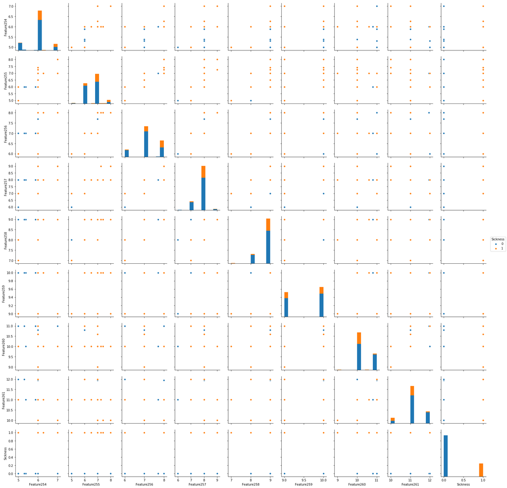

```python
# Those "categorical" features

list_of_cols = merged_df.columns[254:262].tolist()
sns.pairplot(merged_df[list_of_cols + ['Sickness']], hue='Sickness');
```

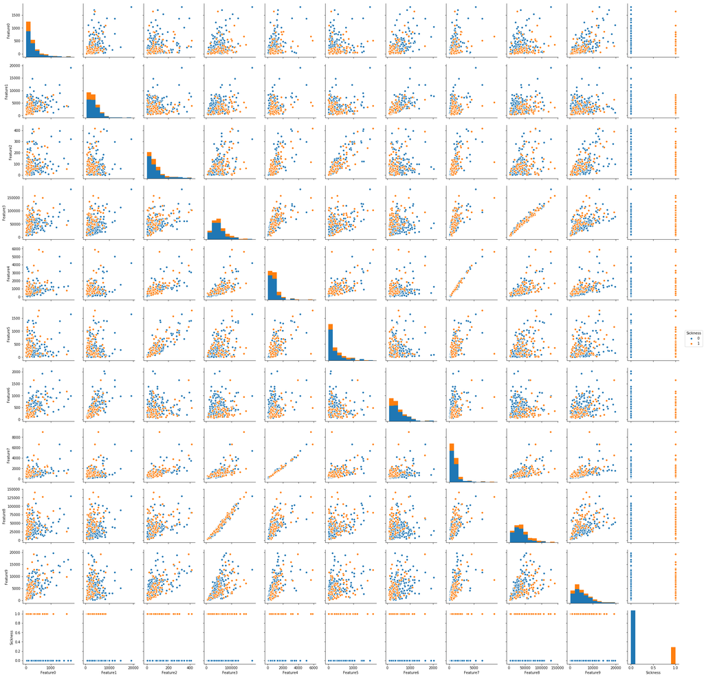

```python
# Some first features

list_of_cols = merged_df.columns[0:10].tolist()
sns.pairplot(merged_df[list_of_cols + ['Sickness']], hue='Sickness');
```

Some features are clearly correlated and from the first sight (and in first 10 features) there are no features in these first 10, which can linearly separate ill and healthy guys (oh no). One of the possible directions for the research would be to study the relation between variables. for example, we can build corr_matrix.

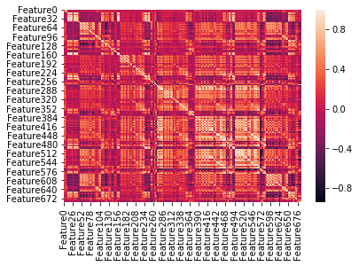

```python
# We see many correlated features

corr_matrix = merged_df.drop(['Sickness'], axis=1).corr()

sns.heatmap(corr_matrix);
```

For now, let's try to visualize the data in a different way -- first we apply PCA to reduce the noise and get less (but more informative features), then we can try to look into multispace of these new features using t-SNE.

```
CPU times: user 3.26 s, sys: 344 ms, total: 3.6 s
Wall time: 3.61 s
```

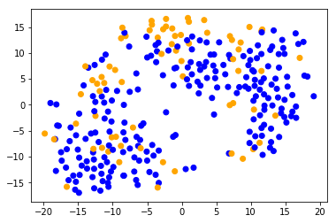

```python
%%time

# Let's scale first

scaler = StandardScaler()
feature_columns = [col for col in merged_df.columns if col != "Sickness"]
merged_df_scaled = scaler.fit_transform(merged_df[feature_columns])

# Then apply PCA with 50 features, for example

pca = PCA(n_components=50, random_state=RANDOM_STATE)
pca_representation = pca.fit_transform(merged_df_scaled)

# Then use t-SNE from sklearn. Though it's not that efficient (there is an open-source lib with much better
# performance and flexibility) we can use it to get a sense of the data

tsne = TSNE(learning_rate=300, random_state=RANDOM_STATE)
tsne_representation = tsne.fit_transform(pca_representation)

plt.scatter(tsne_representation[:, 0], tsne_representation[:, 1],
            c=merged_df["Sickness"].map({0: 'blue', 1: 'orange'}));
```

We can see that sick people sometimes are close to each other and form groups (see the top of the picture), but not always -- others are hiding among healthy ones.

# Some machine learning

Let's split the data into two parts -- train data (we will use cross-validation on it) and a hold-out set.

We don't have much data, especially we don't have many 1's, so it's better to use cv, instead of train-val-test split. But we still have some hold-out to check our unbiased performance. Moreover, we need to stratify the data according to the initial distribution.

```python
feature_columns = [col for col in merged_df.columns if col != "Sickness"]

X_train, X_test, y_train, y_test = train_test_split(merged_df[feature_columns],
                                                    merged_df["Sickness"],
                                                    stratify=merged_df["Sickness"],
                                                    test_size=0.25, random_state=RANDOM_STATE)
```

```python
# We will also keep track of our models to compare their predictions (if the person is sick) in the end

error_analysis = pd.DataFrame(columns=['pca_log_reg', 'select_from_model_log_reg'], index=X_test.index)
```

Let us start with something simple and powerful -- logistic regression. We can create a simple pipeline to find best parameters using GridSearch.

We will look (and ask our algorithms to look) for better recall of the class 1, because we can make some false positives, but we want to keep false negative as low as possible. In other words, we want to detect all (as many as possible) sick people and it's OK for us to confuse some healthy guy with a sick one.

```python
# Scale for better convergence

scaler = StandardScaler()

C_values = [0.001, 0.01, 0.05, 0.1, 1.]

param_grid = {'logisticregression__C': C_values,
              'logisticregression__penalty': ['l1', 'l2']}

clf = LogisticRegression(random_state=RANDOM_STATE)

pipeline = make_pipeline(scaler, clf)

estimator = GridSearchCV(pipeline, param_grid=param_grid, scoring='recall', cv=3)
estimator.fit(X_train, y_train)

print("Mean recall for the 1 class across the folds on cv: {0} \n".format(estimator.best_score_))
print("Best estimator: \n {0} \n".format(estimator.best_estimator_))
print("Classification report for holdout: \n", classification_report(y_test,
                                                                    estimator.best_estimator_.predict(X_test)))

error_analysis['log_reg'] =  estimator.predict_proba(X_test)[:, 1]
```

```
Mean recall for the 1 class across the folds on cv: 0.7136437908496732

Best estimator:
 Pipeline(memory=None,
     steps=[('standardscaler', StandardScaler(copy=True, with_mean=True, with_std=True)), ('logisticregression', LogisticRegression(C=0.001, class_weight=None, dual=False, fit_intercept=True,
          intercept_scaling=1, max_iter=100, multi_class='ovr', n_jobs=1,
          penalty='l2', random_state=42, solver='liblinear', tol=0.0001,
          verbose=0, warm_start=False))])

Classification report for holdout:
              precision    recall  f1-score   support

          0       0.97      0.64      0.77        55
          1       0.44      0.94      0.60        17

avg / total       0.85      0.71      0.73        72
```

The mean recall on cv is 0.71, which is not that high as it is in the hold-out (simply more samples). The precision for 1 class is quite low, seems the algorithm is too aggresively tries to put everyone in sick class. Another way to justify it -- just look at the C value, it's pretty low (0.001), so gridSearch tried to find optimal parameters from given set to increase recall of the 1 class.

We can try to do better. We have many features, maybe we can try to reduce the dimensionality (using PCA for example) for obtaining (hopefully) more informative features. Later we can try to select the features based on the model (using feature importance weights)

```python
scaler = StandardScaler()
pca = PCA(random_state=RANDOM_STATE)

param_grid = {'pca__n_components': [2, 5, 10, 20, 30, 40, 50],
              'logisticregression__C': [0.001, 0.01, 0.05, 0.1, 1., 1.2],
              'logisticregression__penalty': ['l1', 'l2']}

clf = LogisticRegression(random_state=RANDOM_STATE)

pipeline = make_pipeline(scaler, pca, clf)

estimator = GridSearchCV(pipeline, param_grid=param_grid, scoring='recall', cv=3, n_jobs=-1)
estimator.fit(X_train, y_train)

print("Mean recall for the 1 class across the folds on cv: {0} \n".format(estimator.best_score_))
print("Best estimator: \n {0} \n".format(estimator.best_estimator_))
print("Classification report for holdout: \n", classification_report(y_test,
                                                                    estimator.best_estimator_.predict(X_test)))

error_analysis['pca_log_reg'] =  estimator.predict_proba(X_test)[:, 1]
```

```
Mean recall for the 1 class across the folds on cv: 0.751755022996853

Best estimator:
 Pipeline(memory=None,
     steps=[('standardscaler', StandardScaler(copy=True, with_mean=True, with_std=True)), ('pca', PCA(copy=True, iterated_power='auto', n_components=30, random_state=42,
  svd_solver='auto', tol=0.0, whiten=False)), ('logisticregression', LogisticRegression(C=0.001, class_weight=None, dual=False, fit_intercept=True,
          intercept_scaling=1, max_iter=100, multi_class='ovr', n_jobs=1,
          penalty='l2', random_state=42, solver='liblinear', tol=0.0001,
          verbose=0, warm_start=False))])

Classification report for holdout:
              precision    recall  f1-score   support

          0       0.97      0.64      0.77        55
          1       0.44      0.94      0.60        17

avg / total       0.85      0.71      0.73        72
```

We can see that holdout values didn't change, but we have an increase on mean cv score.

Let us try to do feature selection with the help of the model, I will use simple logreg as a baseline.

```python
scaler = StandardScaler()

param_grid = {'logisticregression__C': [0.001, 0.01, 0.05, 0.1, 1., 1.2],
              'logisticregression__penalty': ['l1', 'l2'],
              'selectfrommodel__estimator__C': [0.05, 0.1, 1., 1.2],
              'selectfrommodel__estimator__penalty': ['l1', 'l2'],
              'selectfrommodel__threshold': ['mean', 'median', None]
             }

lr = LogisticRegression(random_state=RANDOM_STATE)

fs = SelectFromModel(estimator=lr)

pipeline = make_pipeline(scaler, fs, lr)

estimator = GridSearchCV(pipeline, param_grid=param_grid, scoring='recall', cv=3, n_jobs=-1)
estimator.fit(X_train, y_train)

print("Best mean recall for the 1 class across the folds on cv: {0} \n".format(estimator.best_score_))
print("Best estimator: \n {0} \n".format(estimator.best_estimator_))
print("Classification report for holdout: \n", classification_report(y_test,
                                                                    estimator.best_estimator_.predict(X_test)))

error_analysis['select_from_model_log_reg'] =  estimator.predict_proba(X_test)[:, 1]
```

```
Best mean recall for the 1 class across the folds on cv: 0.7713628661341079

Best estimator:
 Pipeline(memory=None,
     steps=[('standardscaler', StandardScaler(copy=True, with_mean=True, with_std=True)), ('selectfrommodel', SelectFromModel(estimator=LogisticRegression(C=1.0, class_weight=None, dual=False, fit_intercept=True,
          intercept_scaling=1, max_iter=100, multi_class='ovr', n_jobs=1,
          penalty=...alty='l2', random_state=42, solver='liblinear', tol=0.0001,
          verbose=0, warm_start=False))])

Classification report for holdout:
              precision    recall  f1-score   support

          0       0.97      0.60      0.74        55
          1       0.42      0.94      0.58        17

avg / total       0.84      0.68      0.70        72
```

We again see some increase in mean cv score, but now there is a drop in recall of 0's class.

```python
# We can add true label to our holdout set predictions to see where we make mistakes

error_analysis['Sickness'] = y_test.values
```

```python
error_analysis.head()
```

|  | pca_log_reg | select_from_model_log_reg | log_reg | Sickness |
| --- | --- | --- | --- | --- |
| 251 | 0.527084 | 0.532131 | 0.536636 | 1 |
| 116 | 0.351045 | 0.417177 | 0.365590 | 1 |
| 250 | 0.275388 | 0.308343 | 0.281470 | 0 |
| 155 | 0.369727 | 0.406460 | 0.370188 | 0 |
| 277 | 0.655828 | 0.615126 | 0.647044 | 1 |

We are interested why we are missing our sick guys, why we don't catch them? Let us look at some of them

```python
# Let's choose the ones, where all algorithms fail (< 0.5 predicted_proba). We also can think of the
# threshold tuning in the future

error_analysis[(error_analysis['pca_log_reg'] < 0.5) &
               (error_analysis['select_from_model_log_reg'] < 0.5) &
               (error_analysis['log_reg'] < 0.5) &
               (error_analysis['Sickness'] == 1)]
```

|  | pca_log_reg | select_from_model_log_reg | log_reg | Sickness |
| --- | --- | --- | --- | --- |
| 116 | 0.351045 | 0.417177 | 0.36559 | 1 |

So the only one guy from our holdout got misclassified (of course, it's a matter of random_state, try for example 1121, it will be three of them and cv score will be bigger)

Let's look at the coefficients of the model, they will tell us more about important features. Later we can compare these features on the objects, where the model made a mistake.

[figure not shown]

```python
clf = estimator.best_estimator_.named_steps['logisticregression']

# we will take abs() here, though it would be better
# to study both pos and neg coefs as they "push" to different classes

feature_importance = abs(clf.coef_[0])
feature_importance = 100.0 * (feature_importance / feature_importance.max())
# let's take top 10
sorted_idx = np.argsort(feature_importance)[:10]
pos = np.arange(sorted_idx.shape[0]) + .5

featfig = plt.figure()
featax = featfig.add_subplot(1, 1, 1)
featax.barh(pos, feature_importance[sorted_idx], align='center')
featax.set_yticks(pos)
featax.set_yticklabels(np.array(X_train.columns)[sorted_idx], fontsize=8)
featax.set_xlabel('Relative Feature Importance')

plt.tight_layout()
plt.show()
```

So let's look at the Feature128. It has a pretty big (and actually a bit "scary" big) relative importance. It could be a leakage.

```python
merged_holdout = X_test
merged_holdout['Sickness'] = y_test
```

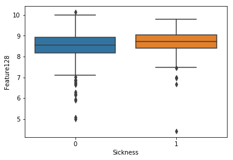

```python
# Distribution on the whole data

sns.boxplot(x='Sickness', y='Feature128', data=merged_df)
```

The typical range of this feature is overlapped a bit for both classes in the data, but in our holdout it's a bit different:

```python
merged_holdout = X_test
merged_holdout['Sickness'] = y_test
```

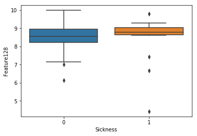

```python
# Distribution on the merged_holdout

sns.boxplot(x='Sickness', y='Feature128', data=merged_holdout)
```

```python
print("Sick Feature128 mean: ", merged_df[merged_df['Sickness'] == 1].Feature128.mean())

print("Healthy Feature128 mean: ", merged_df[merged_df['Sickness'] == 0].Feature128.mean())
```

```
Sick Feature128 mean:  8.565957270325095
Healthy Feature128 mean:  8.448712816358157
```

```python
# Medians are more distant than means (and they are stable in case of outliers)

print("Sick Feature128 median: ", np.median(merged_df[merged_df['Sickness'] == 1].Feature128))

print("Healthy Feature128 median: ", np.median(merged_df[merged_df['Sickness'] == 0].Feature128))
```

```
Sick Feature128 median:  8.714285850524902
Healthy Feature128 median:  8.542857265472412
```

```python
# The value of the misclassified guy

print(X_test[X_test.index == 116].Feature128)
```

```
116    8.805714
Name: Feature128, dtype: float64
```

Here are the things, for which I didn't have time:

1. make 'make_pipeline' flexible and get rid of the repeatable code (though I always do it for production and after some time with research notebooks)
2. better feature importance exploration. The way the model makes its predictions is crucial, so I would explore key features and maybe find some leakages or insights. This exploration will also lead to discovery of potential outliers -- sick (healthy) people with normal (abnormal) features.
3. we can use several algorithms to blend or stack their predictions. As we saw logreg is pretty brutal.
4. I didn't check for crazy values, though I should look at them. Also I haven't paid any attention to the std of the folds on cv, but this is also important if we want to find some outliers.
5. I will definitely try something special for imbalanced class problems (synthetic examples generation or clever sampling). I've been researching this area, you can check this out if you want to: https://github.com/egorLab/tutorials-and-posts/blob/master/imbalanced_problems_labintcev_english.ipynb
6. I didn't try any feature engineering, though even simple multiplications and squaring could work.

Here are the things, which didn't work:

1. k-best feature_selection with SelectKBest, f_classif, mutual_info_classif.
2. tree models and ensembles on top of pca.
3. VarianceThreshold feature selection.